# Electricity demand modelling on GEFCom14 data: solution

Matteo Fasiolo

2019-09-20

1. Load data and have a look at it

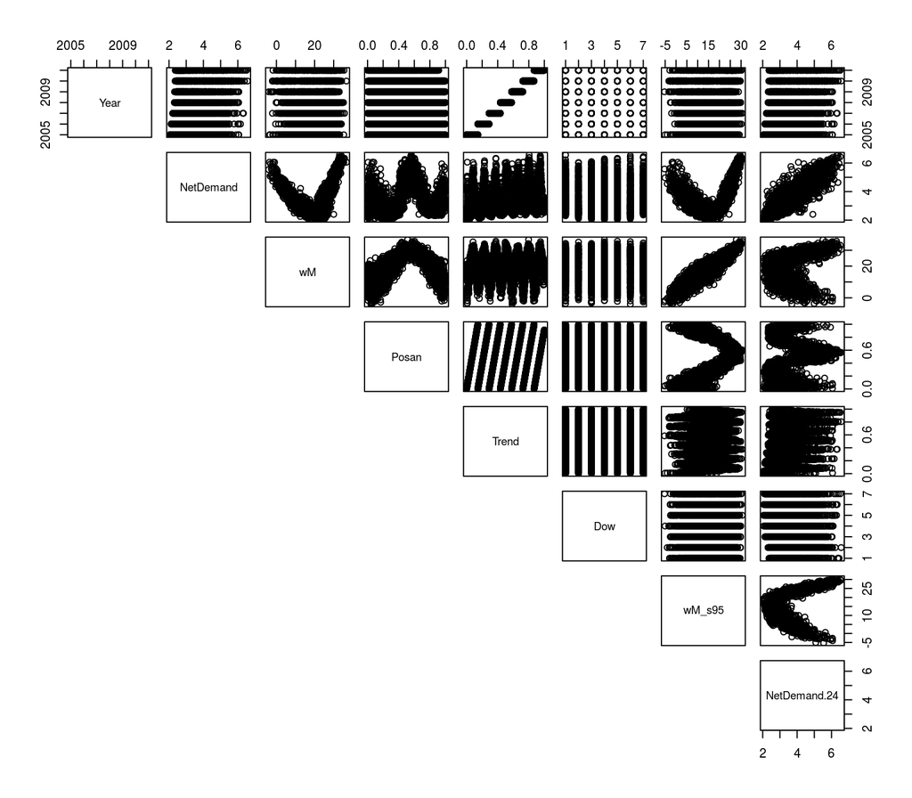

```r
library(testGam)
data("gefcom_small")

pairs(gefcom_small, lower.panel = NULL)
```

2. Fit a basic Gaussian GAM and visualise the fitted effects

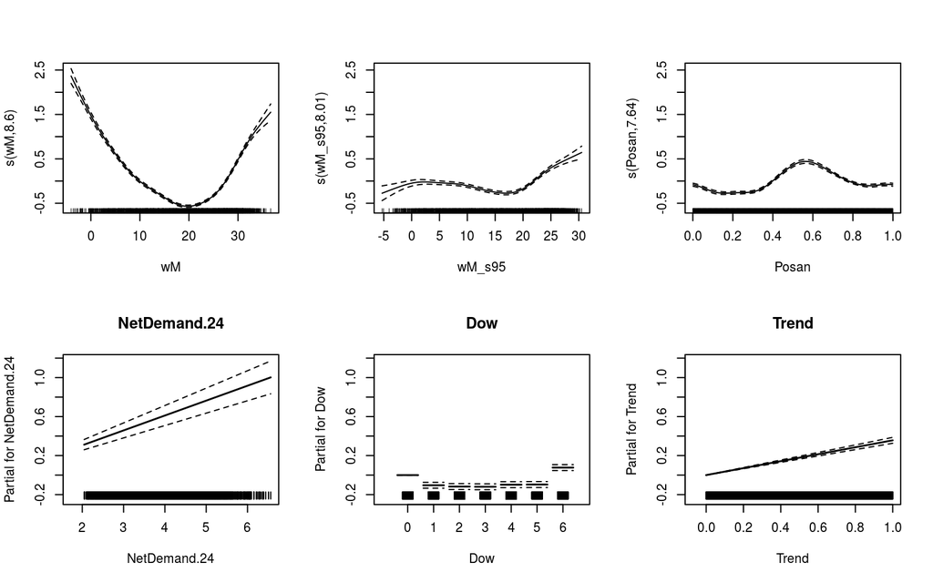

```r
library(mgcv)
fit1 <- gam(NetDemand ~ NetDemand.24 + Dow + Trend + s(wM) + s(wM_s95) + s(Posan, bs = "cc"),
             data = gefcom_small)

plot(fit1, all.terms = TRUE, pages = 1)
```

The effect of instantaneous external temperature seems to be the strongest one.

3. We check the residuals as a function of time (`trend`):

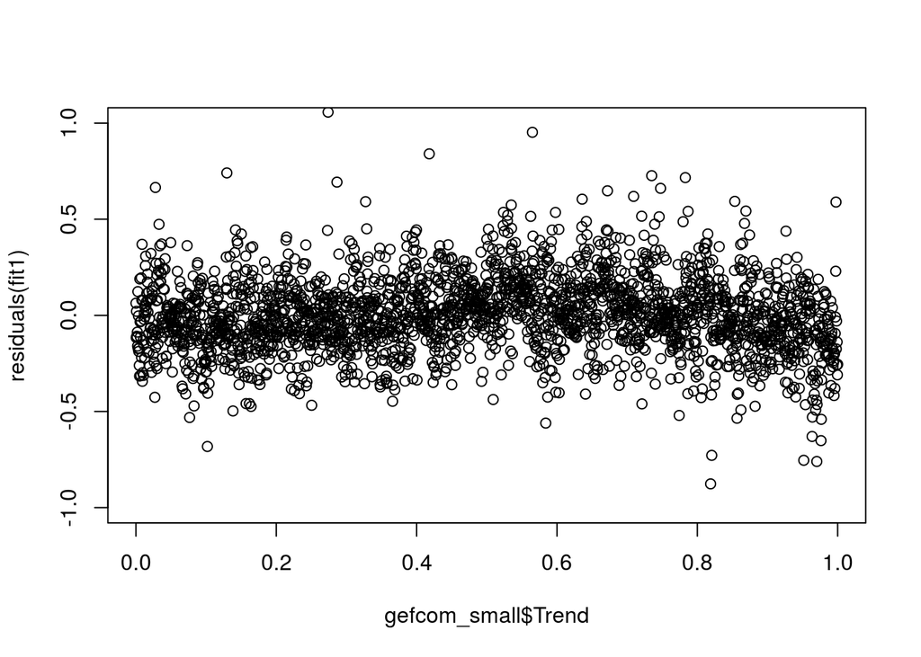

```r
plot(gefcom_small$Trend, residuals(fit1), ylim = c(-1, 1))
```

The long term trend seems to be non-linear. We also check whether we should increase the bases dimension of the other effects:

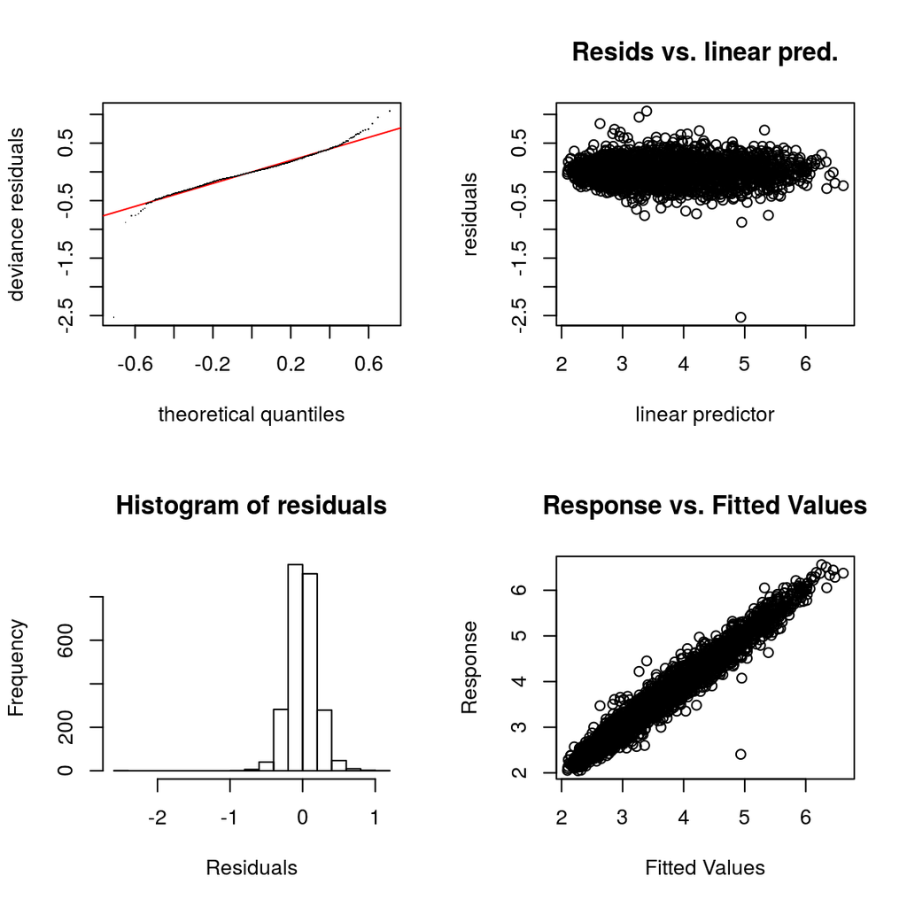

```
##
## Method: GCV   Optimizer: magic
## Smoothing parameter selection converged after 11 iterations.
## The RMS GCV score gradient at convergence was 5.666591e-07 .
## The Hessian was positive definite.
## Model rank =  35 / 35
##
## Basis dimension (k) checking results. Low p-value (k-index<1) may
## indicate that k is too low, especially if edf is close to k'.
##
##             k'  edf k-index p-value
## s(wM)     9.00 8.60    0.91  <2e-16 ***
## s(wM_s95) 9.00 8.01    1.02    0.77
## s(Posan)  8.00 7.64    1.04    0.98
## ---
## Signif. codes:  0 '***' 0.001 '**' 0.01 '*' 0.05 '.' 0.1 ' ' 1
```

```r
par(mfrow = c(2, 2))
gam.check(fit1)
```

`edf` is quite close to `k'` for all effects, and we get a very low p-value for `wM`. We have to increase `k` a bit.

4. Re-fit with a smooth long-term trend and increase basis dimension:

```r
fit2 <- gam(NetDemand ~ NetDemand.24 + Dow + s(Trend, k = 6) + s(wM, k = 20) +
             s(wM_s95, k = 15) + s(Posan, k = 15, bs = "cc"),
            data = gefcom_small)

AIC(fit1, fit2)
```

```
##            df        AIC
## fit1 34.25210  -924.4253
## fit2 49.53941 -1190.9411
```

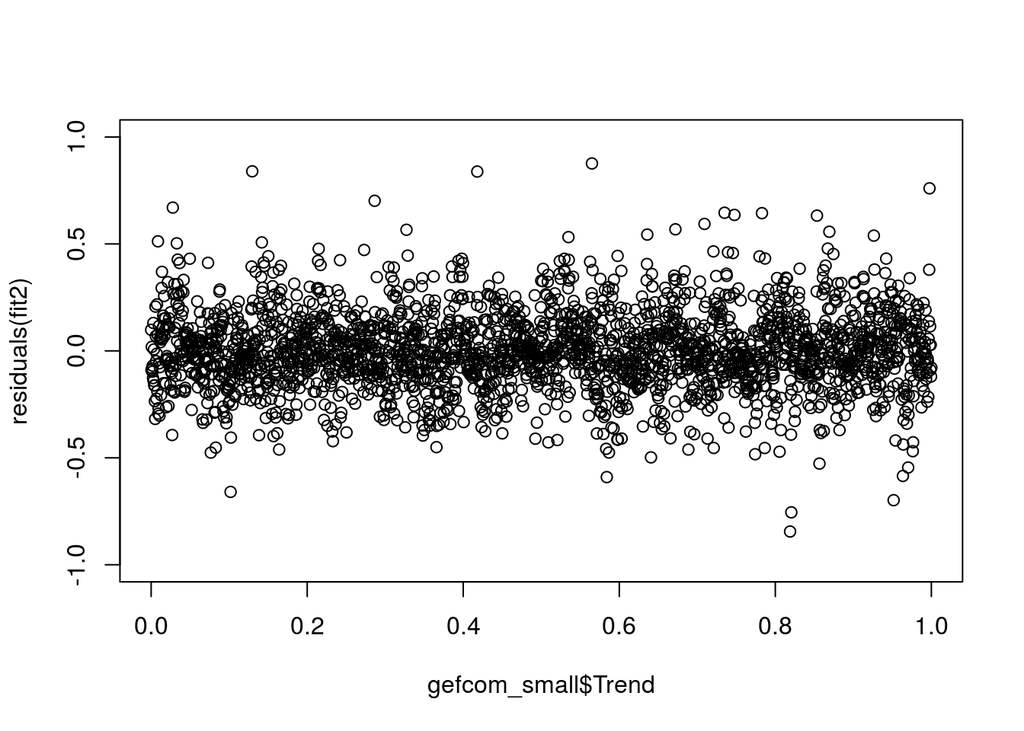

```r
plot(gefcom_small$Trend, residuals(fit2), ylim = c(-1, 1))
```

AIC is much improved, and there is no systematic residual pattern along `trend`. We recheck using `check`:

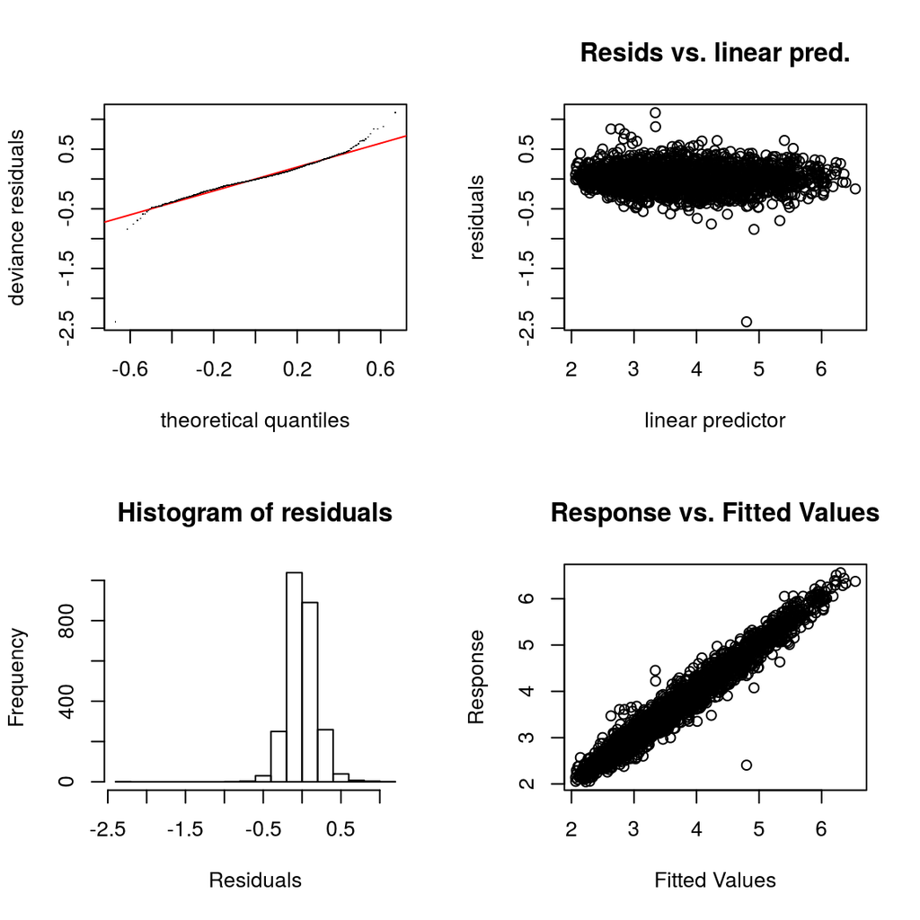

```
##
## Method: GCV   Optimizer: magic
## Smoothing parameter selection converged after 7 iterations.
## The RMS GCV score gradient at convergence was 1.528676e-06 .
## The Hessian was positive definite.
## Model rank =  59 / 59
##
## Basis dimension (k) checking results. Low p-value (k-index<1) may
## indicate that k is too low, especially if edf is close to k'.
##
##              k'   edf k-index p-value
## s(Trend)   5.00  4.28    0.78  <2e-16 ***
## s(wM)     19.00 15.64    0.96    0.02 *
## s(wM_s95) 14.00  8.85    1.02    0.81
## s(Posan)  13.00 11.77    1.00    0.58
## ---
## Signif. codes:  0 '***' 0.001 '**' 0.01 '*' 0.05 '.' 0.1 ' ' 1
```

```r
par(mfrow = c(2, 2))
gam.check(fit2)
```

Maybe we should increase the basis dimension for `wM` a bit more. But increasing the basis dimension for `Trend` too much is definitely not a good idea, because we would end up interpolating the data.

5. Look at a QQ-plot:

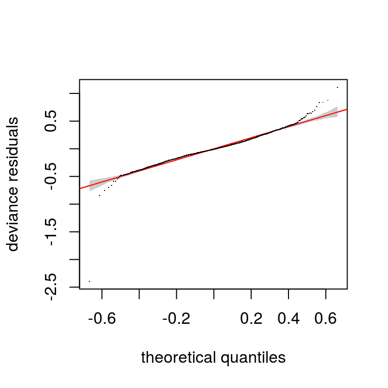

```r
qq.gam(fit2, rep = 100)
```

We have some fairly fat tails, maybe better to adopt a scaled student-t distribution:

```r
fit3 <- gam(NetDemand ~ NetDemand.24 + Dow + s(Trend, k = 6) + s(wM, k = 20) +
             s(wM_s95, k = 15) + s(Posan, k = 15, bs = "cc"), data = gefcom_small,
             family = scat)

AIC(fit2, fit3)
```

```
##            df       AIC
## fit2 49.53941 -1190.941
## fit3 52.62095 -1469.572
```

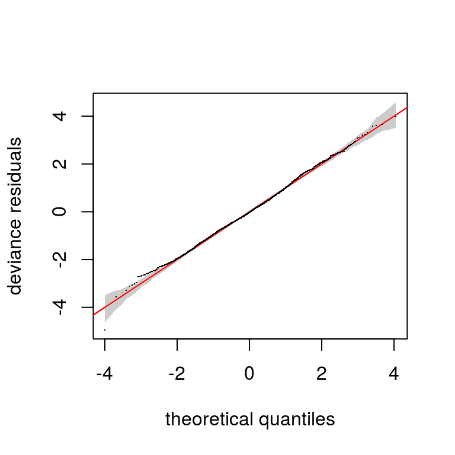

```r
qq.gam(fit3, rep = 100)
```

Better AIC, and the QQ-plot looks much better.

6. Worth considering the log-link, as an alternative to the identity link:

```r
fit4 <- gam(NetDemand ~ NetDemand.24 + Dow + s(Trend, k = 6) + s(wM, k = 20) +
             s(wM_s95, k = 15) + s(Posan, k = 15, bs = "cc"),
             data = gefcom_small,
             family = scat(link = log))

AIC(fit3, fit4)
```

```
##            df       AIC
## fit3 52.62095 -1469.572
## fit4 53.18697 -1490.069
```

Seems better in terms of AIC. We finally plot the fitted effects:

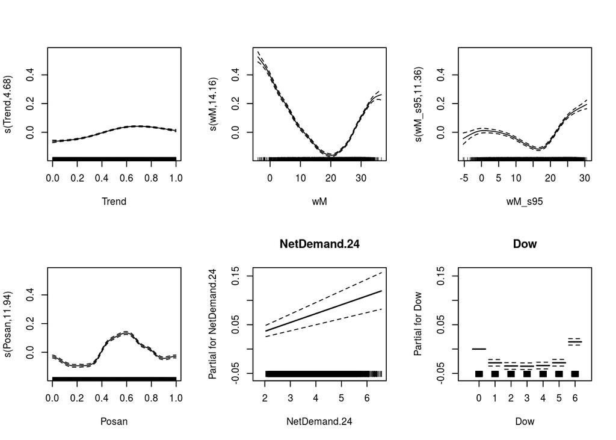

```r
plot(fit4, all.terms = TRUE, pages = 1)
```